```r
library(readr)
library(dplyr)
```

#Intro This project’s goal is to find stocks that are positively correlated and then package the pairs together and make trades based on the movements of their pairs.

#Setup Code This chunk gets a list of all the stock files in a folder that are csvs and finds the correlation between the x stocks selected and outputs that data in a data frame along with the two stocks selected for each.

```r
stock_correlation = data.frame(Correlation = numeric(), Stock1 = character(), Stock2 = character(), index1 = numeric(), index2 = numeric(), stringsAsFactors = FALSE) #data frame setup

files = list.files(path = "./data/", pattern = '\\.csv$', full.names = TRUE) #gets a list of all files in the data path
stock1 = read.csv(files[1])
print(stock1[1,]) #Shows row 1 of the data we use
```

```
##         Date  Open  High   Low Close Adj.Close  Volume
## 1 2017-03-31 53.07 53.23 52.81 52.87  50.91416 1705600
```

```r
num_stocks = 100 #Selects how many stocks used, goes by alphabetical order
iterator = 1

combine_two_stocks = function(a, b, stockNames = c(deparse(substitute(a)), deparse(substitute(b)))) { #Finds common dates where both stacks were traded
    rr = range(intersect(a$Date, b$Date))
    a.sub = a[a$Date >= rr[1] & a$Date <= rr[2],]
    b.sub = b[b$Date >= rr[1] & b$Date <= rr[2],]
    structure(data.frame(a.sub$Date, a.sub$Adj.Close, b.sub$Adj.Close), names = c("Date", stockNames))
}
for (i in 1: num_stocks) {
    for (j in 1: num_stocks) {
        files = list.files(path = "./data/", pattern = '\\.csv$', full.names = TRUE)
        stock1 = read.csv(files[i])
        stock2 = read.csv(files[j])

        overlap = combine_two_stocks(stock1, stock2)

        if (files[i] != files[j]) { #Prevents the code from having it compare stocks to itself
            name1 = substring(files[i], 8)
            name1 = substr(name1, 1, nchar(name1) - 4) #Stock name without the folder name and file extension
            name2 = substring(files[j], 8)
            name2 = substr(name2, 1, nchar(name2) - 4) #Stock name without the folder name and file extension

            stock_correlation[iterator, ] = list(cor(overlap$stock1, overlap$stock2), name1, name2, i, j)

            iterator = iterator + 1
        }
    }
}

ordered_correlation = stock_correlation[order(stock_correlation$Correlation, decreasing = TRUE), ]
reverse_ordered_correlation = stock_correlation[order(stock_correlation$Correlation, decreasing = FALSE), ]

unique_ordered_correlation <-ordered_correlation[!duplicated(ordered_correlation[, c("Correlation")]), ]
reverse_unique_ordered_correlation <-reverse_ordered_correlation[!duplicated(reverse_ordered_correlation[, c("Correlation")]), ]

print(head(unique_ordered_correlation)) #Prints the 6 highest correlated stocks
```

```
##      Correlation Stock1 Stock2 index1 index2
## 812    0.9852435    ACN    AJG      9     21
## 2049   0.9841004    AJG    BRO     21     70
## 1020   0.9814527    ADI    AME     11     31
## 834    0.9809534    ACN    APH      9     43
## 76     0.9798025      A   CARR      1     77
## 326    0.9790810   AAPL    AMD      4     30
```

```r
print(head(reverse_unique_ordered_correlation)) #Prints the 6 lowest correlated stocks
```

```
##      Correlation Stock1 Stock2 index1 index2
## 2161  -0.8855447   AKAM    CCL     22     83
## 8101  -0.8797237    CCI    CCL     82     83
## 3349  -0.8763056    AMT    CCL     34     83
## 8215  -0.8755817    CCL    CLX     83     98
## 132   -0.8755003    AAL    AMT      2     34
## 190   -0.8748775    AAL    CHD      2     92
```

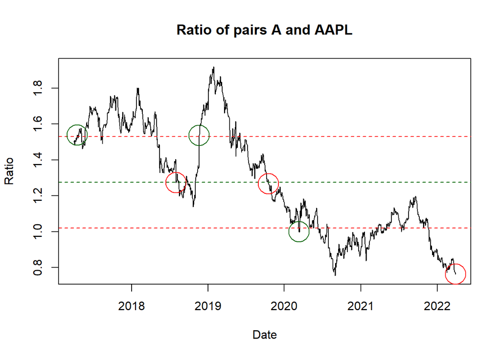

```r
files = list.files(path = "./data/", pattern = '\\.csv$', full.names = TRUE)
stock1num = 1
stock2num = 4

stock1 = read.csv(files[stock1num]) #A
stock2 = read.csv(files[stock2num]) #AAPL

name1 = substring(files[stock1num], 8)
name1 = substr(name1, 1, nchar(name1) - 4) #Stock name without the folder name and file extension
name2 = substring(files[stock2num], 8)
name2 = substr(name2, 1, nchar(name2) - 4) #Stock name without the folder name and file extension

combine_two_stocks = function(a, b, stockNames = c(deparse(substitute(a)), deparse(substitute(b)))) {#Finds common dates where both stacks were traded
    rr = range(intersect(a$Date, b$Date))
    a.sub = a[a$Date >= rr[1] & a$Date <= rr[2], ]
    b.sub = b[b$Date >= rr[1] & b$Date <= rr[2], ]
    structure(data.frame(a.sub$Date, a.sub$Adj.Close, b.sub$Adj.Close), names = c("Date", stockNames))
}

overlap = combine_two_stocks(stock1, stock2)
r = overlap$stock1 / overlap$stock2
k = .85 #Standard deviation

plot_ratio = function(r, k = 1, date = seq(along = r), ...) { #function that plots the ratio of correlation between stock1 and stock2
    plot(date, r, type = "l", main = paste("Ratio of pairs", name1, "and", name2, sep = " "),...)
    abline(h = c(mean(r), mean(r) + k * sd(r), mean(r) - k * sd(r)), col = c("darkgreen", rep("red", 2 * length(k))), lty = "dashed")
}
overlap$Date = as.Date(overlap$Date, format = c("%Y-%m-%d")) #Converts overlap$Date into a R readable format

find_next_position = function(ratio, startDay = 1, k = 1, m = mean(ratio), s = sd(ratio)) { #function that finds which stock to find which stock to buy or sell
    up = m + k * s
    down = m - k * s
    if (startDay > 1)
        ratio = ratio[-(1: (startDay - 1))]
    is_extreme = ratio >= up | ratio <= down
    if (!any(is_extreme))
        return (integer())
    start = which(is_extreme)[1]
    back_to_normal = if (ratio[start] > up)
            ratio[-(1: start)] <= m
    else
        ratio[-(1: start)] >= m
    end = if (any(back_to_normal))
            which(back_to_normal)[1] + start
    else
        length(ratio)
    c(start, end) + startDay - 1
}

show_position = function(days, ratios, radius = 50) { #Draws circles on graph where the ratio is optimal to buy or sell
    symbols(days, ratios, circles = rep(radius, 2), fg = c("darkgreen", "red"), add = TRUE, inches = FALSE)
}

get_positions = function(ratio, k = 1, m = mean(ratio), s = sd(ratio)) { #Finds Where the ratio is optimal to buy or sell
    when = list()
    cur = 1
    while (cur < length(ratio)) {
        temp = find_next_position(ratio, cur, k, m, s)
        if (length(temp) == 0) #quit
        break
        when[[length(when) + 1]] = temp
        if (is.na(temp[2]) || temp[2] == length(ratio))
            break
        cur = temp[2]
    }
    when
}
pos = get_positions(r, k) #Finds Where the ratio is optimal to buy or sell
plot_ratio(r, k, overlap$Date, xlab = "Date", ylab = "Ratio") #function that plots the ratio of correlation between stock1 and stock2
invisible(lapply(pos, function(p) show_position(overlap$Date[p], r[p])))
```

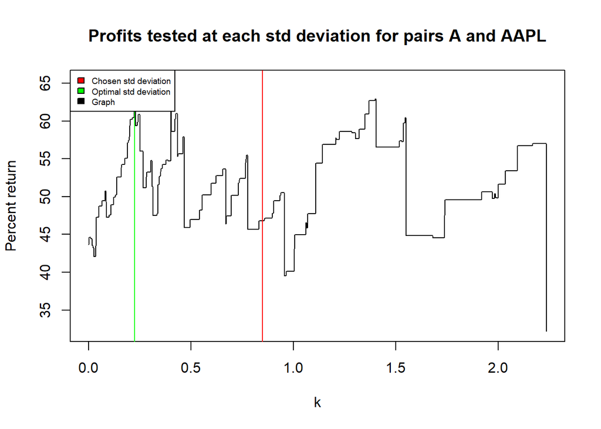

```r
position_profit = function(pos, stock_price_1, stock_price_2, ratio_mean = mean(stock_price_1 / stock_price_2), p = .001, by_stock = FALSE) { #Finds the profit from the purchases
    if (is.list(pos)) {
        ans = sapply(pos, position_profit,
            stock_price_1, stock_price_2, ratio_mean, p, by_stock)
        if (by_stock)
            rownames(ans) = c("A", "B", "commission")
        return (ans)
    }

    price_stock1 = stock_price_1[pos] #Gets prices
    price_stock2 = stock_price_2[pos] #Gets prices

    units_of_stock1 = 1 / price_stock1[1] #Buying dollars_per_trade$ worth of stock
    units_of_stock2 = 1 / price_stock2[1] #Buying dollars_per_trade$ worth of stock

    amount = c(units_of_stock1 * price_stock1[2], units_of_stock2 * price_stock2[2])

    sell_what = if (price_stock1[1] / price_stock2[1] > ratio_mean) "A" #stock that is being sold
    else "B"
    profit = if (sell_what == "A") #Calculates profit
            c((1 - amount[1]), (amount[2] - 1), -p * sum(amount))
    else
        c((1 - amount[2]), (amount[1] - 1), -p * sum(amount))
    if (by_stock)
        profit
    else
        sum(profit)
}

model_iterator = 1:floor(nrow(overlap) / 2)
train = overlap[model_iterator, ]
test = overlap[-model_iterator, ]

r.train = train$stock1 / train$stock2 #Setting up the regression model
r.test = test$stock1 / test$stock2 #Setting up the regression model
train.period = seq(min(overlap$Date), by = "5 years", length = 2)#Creates a regression model

stock1.test = subset(stock1, !(Date >= train.period[1] & Date < train.period[2])) $Adj.Close #Runs regression model
stock2.test = subset(stock2, !(Date >= train.period[1] & Date < train.period[2])) $Adj.Close #Runs regression model
r.test = stock1.test / stock2.test

k.max = max((r.train - mean(r.train)) / sd(r.train))
k.min = min((abs(r.train - mean(r.train)) / sd(r.train)))
ks = seq(k.min, k.max, length = 1000)
m = mean(r.train)

profits = sapply(ks, function(k) { #Creates a list of profits per trade
    pos = get_positions(r.train, k)
    sum(position_profit(pos, train$stock1, train$stock2, mean(r.train)))
})

plot(ks, profits * 100, type = "l", xlab = "k", ylab = "Percent return", main = paste("Profits tested at each std deviation for pairs", name1, "and", name2, sep = " "))
abline(v = k, col = "red")

k.star = mean(ks[profits == max(profits)])
abline(v = k.star, col = 'green')
legend("topleft", legend = c("Chosen std deviation", "Optimal std deviation", "Graph"), fill = c("red", "green", "black"), cex = .60)
```

```r
print(sprintf("%f$ return in %i trades at a %.2f percent profit", sum(profits), length(profits),sum(profits / 1000) * 100))
```

```
## [1] "516.237229$ return in 1000 trades at a 51.62 percent profit"
```

#Output Chunk This chunk outputs the return of the top x in this case 10, most and least correlated pairs based on the amount of days, number of stocks, and dollars per trade inputted. This is very similar to the last chunk but instead it’s ran and iterated as a function and only gives the outputs. The outputs show that the positively correlated stocks have a much greater return than the negatively correlated ones.

```r
trades <- function(days = 1000, num_stocks = 10, dollars_per_trade = 1, index1, index2) {
    files = list.files(path = "./data/", pattern = '\\.csv$', full.names = TRUE)

    for (i in 1: num_stocks) {
        stock1 = read.csv(files[index1[i]]) #Uses the index of the data table instead of the file list
        stock2 = read.csv(files[index2[i]]) #Uses the index of the data table instead of the file list

        name1 = substring(files[index1[i]], 8)
        name1 = substr(name1, 1, nchar(name1) - 4) #Stock name without the folder name and file extension
        name2 = substring(files[index2[i]], 8)
        name2 = substr(name2, 1, nchar(name2) - 4) #Stock name without the folder name and file extension

        combine_two_stocks = function(a, b, stockNames = c(deparse(substitute(a)), deparse(substitute(b)))) { #Finds common dates where both stacks were traded
            rr = range(intersect(a$Date, b$Date))
            a.sub = a[a$Date >= rr[1] & a$Date <= rr[2], ]
            b.sub = b[b$Date >= rr[1] & b$Date <= rr[2], ]
            structure(data.frame(a.sub$Date, a.sub$Adj.Close, b.sub$Adj.Close), names = c("Date", stockNames))
        }

        overlap = combine_two_stocks(stock1, stock2)
        r = overlap$stock1 / overlap$stock2
        k = .85 #Standard deviation

        overlap$Date = as.Date(overlap$Date, format = c("%Y-%m-%d")) #Converts overlap$Date into a R readable format

        find_next_position = function(ratio, startDay = 1, k = 1, m = mean(ratio), s = sd(ratio)) { #function that finds which stock to find which stock to buy or sell
            up = m + k * s
            down = m - k * s
            if (startDay > 1)
                ratio = ratio[-(1: (startDay - 1))]
            is_extreme = ratio >= up | ratio <= down
            if (!any(is_extreme))
                return (integer())
            start = which(is_extreme)[1]
            back_to_normal = if (ratio[start] > up)
                    ratio[-(1: start)] <= m
            else
                ratio[-(1: start)] >= m
            end = if (any(back_to_normal))
                    which(back_to_normal)[1] + start
            else
                length(ratio)
            c(start, end) + startDay - 1
        }

        get_positions = function(ratio, k = 1, m = mean(ratio), s = sd(ratio)) { #Finds Where the ratio is optimal to buy or sell
            when = list()
            cur = 1
            while (cur < length(ratio)) {
                temp = find_next_position(ratio, cur, k, m, s)
                if (length(temp) == 0) #quit
                break
                when[[length(when) + 1]] = temp
                if (is.na(temp[2]) || temp[2] == length(ratio))
                    break
                cur = temp[2]
            }
            when
        }

        pos = get_positions(r, k) #Finds Where the ratio is optimal to buy or sell

        position_profit = function(pos, stock_price_1, stock_price_2, ratio_mean = mean(stock_price_1 / stock_price_2), p = .001, by_stock = FALSE) { #Finds the profit from the purchases
            if (is.list(pos)) {
                ans = sapply(pos, position_profit,
                    stock_price_1, stock_price_2, ratio_mean, p, by_stock)
                if (by_stock)
                    rownames(ans) = c("A", "B", "commission")
                return (ans)
            }

            price_stock1 = stock_price_1[pos] #Gets prices
            price_stock2 = stock_price_2[pos] #Gets prices

            units_of_stock1 = dollars_per_trade / price_stock1[1] #Buying dollars_per_trade$ worth of stock
            units_of_stock2 = dollars_per_trade / price_stock2[1] #Buying dollars_per_trade$ worth of stock

            amount = c(units_of_stock1 * price_stock1[2], units_of_stock2 * price_stock2[2])
            sell_what = if (price_stock1[1] / price_stock2[1] > ratio_mean) "A" #stock that is being sold
            else "B"
            profit = if (sell_what == "A")
                    c((1 - amount[1]), (amount[2] - 1), -p * sum(amount))
            else
                c((1 - amount[2]), (amount[1] - 1), -p * sum(amount))
            if (by_stock)
                profit
            else
                sum(profit)
        }

        model_iterator = 1: floor(nrow(overlap) / 2)
        train = overlap[model_iterator, ]
        test = overlap[-model_iterator, ]

        r.train = train$stock1 / train$stock2
        r.test = test$stock1 / test$stock2
        train.period = seq(min(overlap$Date), by = "5 years", length = 2) #Creates regression model

        stock1.test = subset(stock1, !(Date >= train.period[1] & Date < train.period[2])) $Adj.Close #Runs regression model
        stock2.test = subset(stock2, !(Date >= train.period[1] & Date < train.period[2])) $Adj.Close #Runs regression model
        r.test = stock1.test / stock2.test

        k.max = max((r.train - mean(r.train)) / sd(r.train))
        k.min = min((abs(r.train - mean(r.train)) / sd(r.train)))

        ks = seq(k.min, k.max, length = days)
        m = mean(r.train)

        profits = sapply(ks, function(k) { #Creates a list of profits per trade
            pos = get_positions(r.train, k)
            sum(position_profit(pos, train$stock1, train$stock2, mean(r.train)))
        })

        cat(sprintf("This returned %.2f dollars in %i days between %s and %s which is an %.2f percent profit using %i dollars per trade\n", sum(profits), length(profits), name1, name2, (sum(profits / days) * 100),dollars_per_trade))
    }
}


print("Positively Correlated")
```

```
## [1] "Positively Correlated"
```

```r
trades(1000, 10, 1, unique_ordered_correlation$index1, unique_ordered_correlation$index2)
```

```
## This returned 399.41 dollars in 1000 days between ACN and AJG which is an 39.94 percent profit using 1 dollars per trade
## This returned 237.27 dollars in 1000 days between AJG and BRO which is an 23.73 percent profit using 1 dollars per trade
## This returned 643.07 dollars in 1000 days between ADI and AME which is an 64.31 percent profit using 1 dollars per trade
## This returned 181.36 dollars in 1000 days between ACN and APH which is an 18.14 percent profit using 1 dollars per trade
## This returned 716.50 dollars in 1000 days between A and CARR which is an 71.65 percent profit using 1 dollars per trade
## This returned 911.43 dollars in 1000 days between AAPL and AMD which is an 91.14 percent profit using 1 dollars per trade
## This returned 770.29 dollars in 1000 days between AMD and CDNS which is an 77.03 percent profit using 1 dollars per trade
## This returned 705.50 dollars in 1000 days between ADBE and BIO which is an 70.55 percent profit using 1 dollars per trade
## This returned 296.00 dollars in 1000 days between AJG and AON which is an 29.60 percent profit using 1 dollars per trade
## This returned 189.03 dollars in 1000 days between ACN and CDNS which is an 18.90 percent profit using 1 dollars per trade
```

```r
print("Negatively Correlated")
```

```
## [1] "Negatively Correlated"
```

```r
trades(1000, 10, 1, reverse_unique_ordered_correlation$index1, reverse_unique_ordered_correlation$index2)
```

```
## This returned 72.63 dollars in 1000 days between AKAM and CCL which is an 7.26 percent profit using 1 dollars per trade
## This returned -61.39 dollars in 1000 days between CCI and CCL which is an -6.14 percent profit using 1 dollars per trade
## This returned -95.45 dollars in 1000 days between AMT and CCL which is an -9.55 percent profit using 1 dollars per trade
## This returned 61.67 dollars in 1000 days between CCL and CLX which is an 6.17 percent profit using 1 dollars per trade
## This returned -91.26 dollars in 1000 days between AAL and AMT which is an -9.13 percent profit using 1 dollars per trade
## This returned -73.55 dollars in 1000 days between AAL and CHD which is an -7.36 percent profit using 1 dollars per trade
## This returned 25.76 dollars in 1000 days between ANSS and CCL which is an 2.58 percent profit using 1 dollars per trade
## This returned -124.98 dollars in 1000 days between AWK and CCL which is an -12.50 percent profit using 1 dollars per trade
## This returned 35.61 dollars in 1000 days between AAL and CLX which is an 3.56 percent profit using 1 dollars per trade
## This returned 460.72 dollars in 1000 days between AMZN and CCL which is an 46.07 percent profit using 1 dollars per trade
```